# Working with Words

Danielle Barnas

4/19/2021

gif count: 1

## Load packages

```r
library(here)
library(tidyverse)
library(tidytext)
library(wordcloud2)
library(janeaustenr)
```

# stringr

## Intro to {stringr}

- String and character are the same thing
- You can have several strings in a vector

**Utiliies:**  
Manipulation  
Whitespace tools  
Locale sensitive operations  
Pattern matching functions

## Manipulation

paste() - paste words together, could be all characters, could be a mix of characters and non-character values  
- can specify the kind of separation between

Ex.

```r
paste("High temp", "Low pH")
```

```
## [1] "High temp Low pH"
```

```r
paste("High temp", "Low pH", sep = "-")
```

```
## [1] "High temp-Low pH"
```

paste0() - removes the space between the separate strings

Ex.

```r
paste0("High temp", "Low pH")
```

```
## [1] "High tempLow pH"
```

#### Working with vectors

```r
shapes <- c("square", "circle", "triangle")
paste("My favorite shape is a", shapes)
```

```
## [1] "My favorite shape is a square"   "My favorite shape is a circle"
## [3] "My favorite shape is a triangle"
```

```r
two_cities <- c("best","worst")
paste("It was the", two_cities, "of times.")
```

```
## [1] "It was the best of times."  "It was the worst of times."
```

#### Individual characters

**Legnth of strings**

```r
shapes
```

```
## [1] "square"   "circle"   "triangle"
```

```r
str_length(shapes)
```

```
## [1] 6 6 8
```

**Extract specific characters**

Find, extract, replace at a specific point in the string

```r
seq_data<-c("ATCCCGTC")
str_sub(seq_data,start = 3, end = 3) <- "A"
# start = character number within string to start
# end = character number within string to end
```

Duplicate a string

```r
str_dup(seq_data, times = c(2,3))
```

```
## [1] "ATACCGTCATACCGTC"         "ATACCGTCATACCGTCATACCGTC"
```

```r
# times = number of times you wnat to duplicate the string
```

## Whitespace

```r
badtreatments <-c("High", " High", "High ", "Low", " Low")

# remove all whitespace
str_trim(badtreatments)
```

```
## [1] "High" "High" "High" "Low"  "Low"
```

```r
# remove whitespace from only the left side
str_trim(badtreatments, side = "left")
```

```
## [1] "High"  "High"  "High " "Low"   "Low"
```

Add whitespace

```r
str_pad(badtreatments, 5, side = "right")
```

```
## [1] "High " " High" "High " "Low  " " Low "
```

```r
# the 5 indicates how many total characters to have in each string

str_pad(badtreatments, 5, side = "right", pad = "1")
```

```
## [1] "High1" " High" "High " "Low11" " Low1"
```

```r
# the pad indicates what character to add, default is whitespace
```

## Locale Sensitive

```r
x <- "I love R:"

str_to_upper(x) # ALL CAPS
```

```
## [1] "I LOVE R:"
```

```r
str_to_lower(x) # all lower case
```

```
## [1] "i love r:"
```

```r
str_to_title(x) # First Letter Is Capitalized
```

```
## [1] "I Love R:"
```

## Pattern Matching

view, detect, locate, extract, match, replace, and split strings based on specific patterns

```r
data <- c("AAA", "TATA", "CTAG", "GCTT")

str_view(data, pattern = "CT")
```

[interactive chart not shown]

```r
str_detect(data, pattern = "A")
```

```
## [1]  TRUE  TRUE  TRUE FALSE
```

```r
str_detect(data, pattern = "AT")
```

```
## [1] FALSE  TRUE FALSE FALSE
```

```r
str_locate(data, pattern = "AT")
```

```
##      start end
## [1,]    NA  NA
## [2,]     2   3
## [3,]    NA  NA
## [4,]    NA  NA
```

## Regex: regular expressions

Want to search for something more complicated… like find all the numbers, letters, or special characters.

We will learn:  
Metacharacers  
Sequences  
Quantifiers  
Character classes  
POSIX character classes (Portable Operating System Interface)

## Metacharacters

Use two backslashes to use the metacharacter as a normal character

```r
vals<-c("a.b","b.c","c.d")

str_replace(vals, "\\.", " ")
```

```
## [1] "a b" "b c" "c d"
```

```r
# only replaces the first instance of the pattern character

# check if there is a way to look for second, third, last instance, etc.

vals<-c("a.b.c", "c.d.b", "b.a.c")
str_replace_all(vals, "\\.", " ")
```

```
## [1] "a b c" "c d b" "b a c"
```

```r
# replaces all of that pattern character
```

## Sequences

```r
val2 <- c("test 123", "test 456", "test")

str_subset(val2, "\\d") # finds first instance of anything that has any digits
```

```
## [1] "test 123" "test 456"
```

## Character class

**Quantification of text**

```r
str_count(val2, "[aeiou]")
```

```
## [1] 1 1 1
```

```r
# counts all the values in the string that match any of those items in the brackets

str_count(val2, "[0-9]")
```

```
## [1] 3 3 0
```

## Quantifiers

^ beginning of string $ end of string newline * zero or more of previous ?zero or one of previous {5} exactly 5 previous {2,5} between 2 and 5 of previous expression {2, } 2 or more of previous expression

```r
strings<-c("550-153-7578",
         "banana",
         "435.114.7586",
         "home: 672-442-6739")
```

Make a regex that finds all the strings that contain a phone number. We know there is a specific pattern (3 numbers, 3 numbers, 4 numbers and it can have either a “.” or “-” to separate them). Let’s also say we know that the first number cannot be a 1

```r
phone <- "([2-9][0-9]{2})[- .]([0-9]{3})[- .]([0-9]{4})"
# anything within a bracket is explicit.
# have each argument contianed in parentheses
# first number is any number other than 0 or 1
# then have 2 numbers that can be any number
# then a dash or a dot
# then have three numbers that can be any number
# then a dash or a dot
# then have four numbers that can be any number

phone2 <-"([2-9][\\d]{2})[- .]([\\d]{3})[- .]([\\d]{4})"

# same as above but replaces the 0-9 with the digit sequence identifier
```

If you wanted to find a specific area code, you could have to eitiher write it like [8][1][8] or [“818”]

Then see which of the strings has the correct phone syntax

```r
str_detect(strings, phone)
```

```
## [1]  TRUE FALSE  TRUE  TRUE
```

```r
# kicks out the banana

str_detect(strings, phone2)
```

```
## [1]  TRUE FALSE  TRUE  TRUE
```

## Think, Pair, Share

```r
# subset only the strings with phone numbers
test<-str_subset(strings, phone)
test
```

```
## [1] "550-153-7578"       "435.114.7586"       "home: 672-442-6739"
```

Let’s clean it up. Lets replace all the “.” with “-” and extract only the numbers (leaving the letters behind). Remove any extra white space. You can use a sequence of pipes.

```r
test %>%
  str_replace_all(pattern = "\\.", "-") %>%
  str_replace_all(pattern = "[a-zA-Z] | \\:",replacement = "") %>%
  str_trim()
```

```
## [1] "550-153-7578"       "435-114-7586"       "home: 672-442-6739"
```

# tidytext

```r
head(austen_books())
```

```
## # A tibble: 6 x 2
##   text                    book
##   <chr>                   <fct>
## 1 "SENSE AND SENSIBILITY" Sense & Sensibility
## 2 ""                      Sense & Sensibility
## 3 "by Jane Austen"        Sense & Sensibility
## 4 ""                      Sense & Sensibility
## 5 "(1811)"                Sense & Sensibility
## 6 ""                      Sense & Sensibility
```

```r
tail(austen_books())
```

```
## # A tibble: 6 x 2
##   text                                                               book
##   <chr>                                                              <fct>
## 1 "possible, more distinguished in its domestic virtues than in its" Persuasion
## 2 "national importance."                                             Persuasion
## 3 ""                                                                 Persuasion
## 4 ""                                                                 Persuasion
## 5 ""                                                                 Persuasion
## 6 "Finis"                                                            Persuasion
```

## Clean up and add column for line and chapter

```r
original_books <- austen_books() %>% # all of her books
  group_by(book) %>%
  mutate(line = row_number(), # enumerate every line of the book
         chapter = cumsum(str_detect(text,
                                     regex("^chapter [\\divxlc]",# start with word chapter; then has any digit or roman numeral
                                           ignore_caes = T)))) %>% # can be either an upper case chapter or lower case chapter, and can either be upper case roman numeral or lower case roman numeral
  ungroup()

head(original_books)
```

```
## # A tibble: 6 x 4
##   text                    book                 line chapter
##   <chr>                   <fct>               <int>   <int>
## 1 "SENSE AND SENSIBILITY" Sense & Sensibility     1       0
## 2 ""                      Sense & Sensibility     2       0
## 3 "by Jane Austen"        Sense & Sensibility     3       0
## 4 ""                      Sense & Sensibility     4       0
## 5 "(1811)"                Sense & Sensibility     5       0
## 6 ""                      Sense & Sensibility     6       0
```

In tidytext each word is refered to as a token. The function to unnest the data so that its only one word per row is unnest_tokens().

```r
tidy_books <- original_books %>%
  unnest_tokens(output = word, input = text)
# add a column named word, with the input as the text column
# removes whitepsace and makes everything lowercase


head(tidy_books) # now we can view every individual word/token
```

```
## # A tibble: 6 x 4
##   book                 line chapter word
##   <fct>               <int>   <int> <chr>
## 1 Sense & Sensibility     1       0 sense
## 2 Sense & Sensibility     1       0 and
## 3 Sense & Sensibility     1       0 sensibility
## 4 Sense & Sensibility     3       0 by
## 5 Sense & Sensibility     3       0 jane
## 6 Sense & Sensibility     3       0 austen
```

## Stopwords

Words that are common and don’t really have important meaning (e.g. “and”,“by”,“therefore”…). These are called stopwords. We can use the function “get_stopwords()” to essentially remove these words from our dataframe.

```r
#see an example of all the stopwords
head(get_stopwords())
```

```
## # A tibble: 6 x 2
##   word   lexicon
##   <chr>  <chr>
## 1 i      snowball
## 2 me     snowball
## 3 my     snowball
## 4 myself snowball
## 5 we     snowball
## 6 our    snowball
```

**Remove stopwords**

```r
cleaned_books <- tidy_books %>%
  anti_join(get_stopwords())

head(cleaned_books)
```

```
## # A tibble: 6 x 4
##   book                 line chapter word
##   <fct>               <int>   <int> <chr>
## 1 Sense & Sensibility     1       0 sense
## 2 Sense & Sensibility     1       0 sensibility
## 3 Sense & Sensibility     3       0 jane
## 4 Sense & Sensibility     3       0 austen
## 5 Sense & Sensibility     5       0 1811
## 6 Sense & Sensibility    10       0 chapter
```

```r
cleaned_books %>%
  count(word, sort = T)
```

```
## # A tibble: 14,375 x 2
##    word      n
##    <chr> <int>
##  1 mr     3015
##  2 mrs    2446
##  3 must   2071
##  4 said   2041
##  5 much   1935
##  6 miss   1855
##  7 one    1831
##  8 well   1523
##  9 every  1456
## 10 think  1440
## # … with 14,365 more rows
```

```r
cleaned_books %>%
  group_by(book) %>%
  count(word, sort = T)
```

```
## # A tibble: 39,586 x 3
## # Groups:   book [6]
##    book                word          n
##    <fct>               <chr>     <int>
##  1 Emma                mr         1153
##  2 Mansfield Park      fanny       816
##  3 Emma                emma        786
##  4 Pride & Prejudice   mr          785
##  5 Emma                mrs         699
##  6 Sense & Sensibility elinor      623
##  7 Emma                miss        599
##  8 Pride & Prejudice   elizabeth   597
##  9 Emma                must        567
## 10 Sense & Sensibility mrs         530
## # … with 39,576 more rows
```

**Sentiment analysis**

Look for key words in the text. Here, using the sentiments function, but can search for any key words

```r
sent_word_counts <- tidy_books %>%
  inner_join(get_sentiments()) %>%
  count(word, sentiment, sort = T)

head(sent_word_counts)
```

```
## # A tibble: 6 x 3
##   word   sentiment     n
##   <chr>  <chr>     <int>
## 1 miss   negative   1855
## 2 well   positive   1523
## 3 good   positive   1380
## 4 great  positive    981
## 5 like   positive    725
## 6 better positive    639
```

## Plot it

Pos words as pos numbers and Neg words as neg numbers

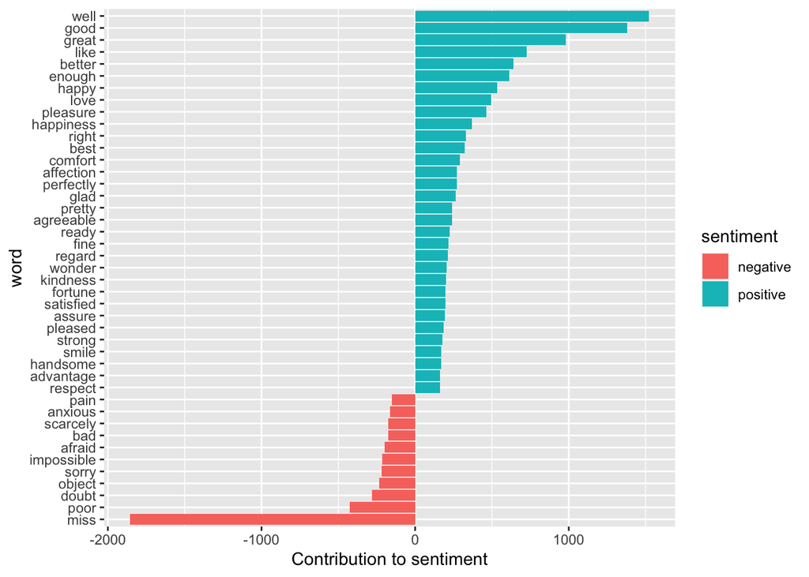

```r
sent_word_counts %>%
  filter(n > 150) %>% # take only if there are over 150 instances of it
  mutate(n = ifelse(sentiment == "negative", -n, n)) %>% # add a column where if the word is negative make the count negative
  mutate(word = reorder(word, n)) %>% # sort it so it gows from largest to smallest
  ggplot(aes(word, n, fill = sentiment)) +
  geom_col() +
  coord_flip() +
  labs(y = "Contribution to sentiment")
```

Wordcloud

```r
words<-cleaned_books %>%
  count(word) %>% # count all the words
  arrange(desc(n))%>% # sort the words
  slice(1:100) #take the top 100

wordcloud2(words, shape = 'triangle', size=0.3) # make a wordcloud out of the top 100 words
```

[interactive chart not shown]

Today’s Totally Awesome R Package ggirl (gg in real life)